# Practical Machine Learning Project-Model Evaluation For Exercise Data Analyais

Raju Vulapalli

May 7, 2016

# Introduction

## Background

People are using devices like Jawbone Up, Fit bit and Nike Fuel Band to monitor their physical exercise activities. These devices generate lot of data and some enthusiasts are using this data to understand their activities to improve their health. People quantify and review how much of a particular activity they perform, but rarely see how well they do it. In this project, an attempt has been made to analyze the data from these devices on the belt, forearm, arm, and dumbbell of six participants. More information is available from the website here: HTTP://groupware.les.inf.puc-rio.br/har (see the section on the Weight Lifting Exercise Data set).

## Data

The training data for this project are available here: https://d396qusza40orc.cloudfront.net/predmachlearn/pml-training.csv The test data are available here: https://d396qusza40orc.cloudfront.net/predmachlearn/pml-testing.csv The data for this project come from this source: http://groupware.les.inf.puc-rio.br/har.

## Getting and loading the data

```r
library(caret)
library(rpart)
```

```r
library(rpart.plot)
library(RColorBrewer)
library(rattle)
library(randomForest)
library(knitr)
library(data.table)
setwd("~/Data Sciences/Practical Machine Learning/Project")
##Getting and loading the data
trainUrl <- "https://d396qusza40orc.cloudfront.net/predmachlearn/pml-training.csv"
testUrl <- "https://d396qusza40orc.cloudfront.net/predmachlearn/pml-testing.csv"

#file names
train.data ="~/Data Sciences/Practical Machine Learning/Project/pml-training.csv"
test.data ="~/Data Sciences/Practical Machine Learning/Project/pml-testing.csv"

# if directory does not exist, create new
if (!file.exists("~/Data Sciences/Practical Machine Learning/Project")) {
  dir.create("~/Data Sciences/Practical Machine Learning/Project")
}
# if files does not exist, download the files
if (!file.exists(train.data)) {
  download.file(trainUrl, destfile=train.data, method="curl")
}
if (!file.exists(test.data)) {
  download.file(testUrl, destfile=test.data, method="curl")
}
# load the CSV files as data.frame
TrainData = read.csv("~/Data Sciences/Practical Machine Learning/Project/pml-training.csv", na.strings=c("NA",""), header=TRUE)
TestData = read.csv("~/Data Sciences/Practical Machine Learning/Project/pml-testing.csv", na.strings=c("NA",""), header=TRUE)
dim(TrainData)
```

```
## [1] 19622   160
```

```r
dim(TestData)
```

```
## [1]  20 160
```

```r
# determine if both training and test data have same columns
colnames_train <- colnames(TrainData)
colnames_test <- colnames(TestData)
# checking if the column names (excluding classe and problem_id) are identical in the training and test set.
all.equal(colnames_train[1:length(colnames_train)-1], colnames_test[1:length(colnames_train)-1])
```

```
## [1] TRUE
```

## Cleaning the data

The columns containing mostly N As and that are not in the test set. Since the test data set has no time dependence, these values are useless an can be excluded from the data analysis. The first seven features are time-series and deleted from the data sets. The resulting columns in both training and test data are verified.

```r
# detemine the number of non-NAs in each col
nonNAs <- function(x) {
  as.vector(apply(x, 2, function(x) length(which(!is.na(x)))))
}

# Build vector of missing data or NA columns to drop.
colcnts <- nonNAs(TrainData)
drops <- c()
for (cnt in 1:length(colcnts)) {
  if (colcnts[cnt] < nrow(TrainData)) {
    drops <- c(drops, colnames_train[cnt])
  }
}

# Since the first 7 columns and NA containing columns are dropped as they're unnecessary for predicting.
TrainData <- TrainData[,!(names(TrainData) %in% drops)]
TrainData <- TrainData[,8:length(colnames(TrainData))]

TestData <- TestData[,!(names(TestData) %in% drops)]
TestData <- TestData[,8:length(colnames(TestData))]

# Show remaining columns.
colnames(TrainData)
```

```
##  [1] "roll_belt"            "pitch_belt"           "yaw_belt"
##  [4] "total_accel_belt"     "gyros_belt_x"         "gyros_belt_y"
##  [7] "gyros_belt_z"         "accel_belt_x"         "accel_belt_y"
## [10] "accel_belt_z"         "magnet_belt_x"        "magnet_belt_y"
## [13] "magnet_belt_z"        "roll_arm"             "pitch_arm"
## [16] "yaw_arm"              "total_accel_arm"      "gyros_arm_x"
## [19] "gyros_arm_y"          "gyros_arm_z"          "accel_arm_x"
## [22] "accel_arm_y"          "accel_arm_z"          "magnet_arm_x"
## [25] "magnet_arm_y"         "magnet_arm_z"         "roll_dumbbell"
## [28] "pitch_dumbbell"       "yaw_dumbbell"         "total_accel_dumbbell"
## [31] "gyros_dumbbell_x"     "gyros_dumbbell_y"     "gyros_dumbbell_z"
## [34] "accel_dumbbell_x"     "accel_dumbbell_y"     "accel_dumbbell_z"
## [37] "magnet_dumbbell_x"    "magnet_dumbbell_y"    "magnet_dumbbell_z"
## [40] "roll_forearm"         "pitch_forearm"        "yaw_forearm"
## [43] "total_accel_forearm"  "gyros_forearm_x"      "gyros_forearm_y"
## [46] "gyros_forearm_z"      "accel_forearm_x"      "accel_forearm_y"
## [49] "accel_forearm_z"      "magnet_forearm_x"     "magnet_forearm_y"
## [52] "magnet_forearm_z"     "classe"
```

```r
colnames(TestData)
```

```
##  [1] "roll_belt"            "pitch_belt"           "yaw_belt"
##  [4] "total_accel_belt"     "gyros_belt_x"         "gyros_belt_y"
##  [7] "gyros_belt_z"         "accel_belt_x"         "accel_belt_y"
## [10] "accel_belt_z"         "magnet_belt_x"        "magnet_belt_y"
## [13] "magnet_belt_z"        "roll_arm"             "pitch_arm"
## [16] "yaw_arm"              "total_accel_arm"      "gyros_arm_x"
## [19] "gyros_arm_y"          "gyros_arm_z"          "accel_arm_x"
## [22] "accel_arm_y"          "accel_arm_z"          "magnet_arm_x"
## [25] "magnet_arm_y"         "magnet_arm_z"         "roll_dumbbell"
## [28] "pitch_dumbbell"       "yaw_dumbbell"         "total_accel_dumbbell"
## [31] "gyros_dumbbell_x"     "gyros_dumbbell_y"     "gyros_dumbbell_z"
## [34] "accel_dumbbell_x"     "accel_dumbbell_y"     "accel_dumbbell_z"
## [37] "magnet_dumbbell_x"    "magnet_dumbbell_y"    "magnet_dumbbell_z"
## [40] "roll_forearm"         "pitch_forearm"        "yaw_forearm"
## [43] "total_accel_forearm"  "gyros_forearm_x"      "gyros_forearm_y"
## [46] "gyros_forearm_z"      "accel_forearm_x"      "accel_forearm_y"
## [49] "accel_forearm_z"      "magnet_forearm_x"     "magnet_forearm_y"
## [52] "magnet_forearm_z"     "problem_id"
```

## Bootstraping

The data is divided into training part (75%) as training1 for model building and initial test training part (25%) as testing1 for model testing.

```r
set.seed(300)
inTrain <- createDataPartition (y=TrainData$classe, p = 0.75, list = F)
training1 = TrainData[inTrain,]
testing1 = TrainData[-inTrain,]
```

## Model building

### Evaluation by decession tress analysis

First model using secession tree is evaluated using the out-of-box rpart functionality

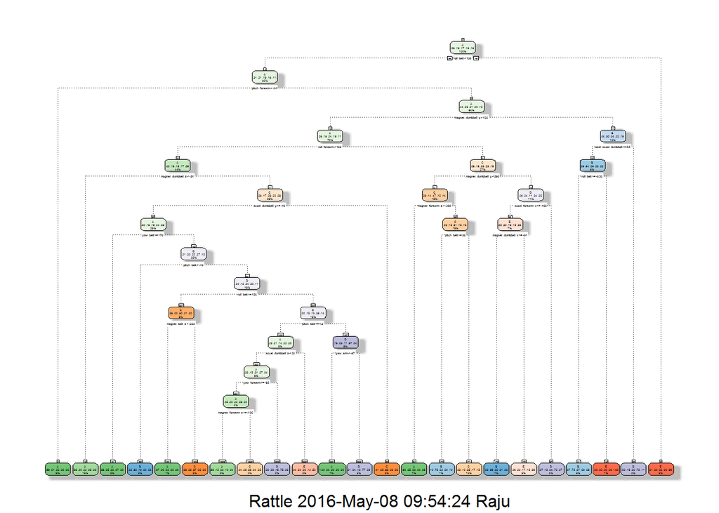

```r
set.seed(12345)
modfFit1 <- rpart(classe~., data = training1, method = "class")
fancyRpartPlot(modfFit1)
```

```r
predictions1 <- predict(modfFit1, testing1, type = "class")
confMatrixTree1 <- confusionMatrix(predictions1, testing1$classe)
confMatrixTree1
```

```
## Confusion Matrix and Statistics
##
##           Reference
## Prediction    A    B    C    D    E
##          A 1285  193   24   59   35
##          B   36  480   44   18   48
##          C   39   90  685  124  110
##          D   17   61   45  535   42
##          E   18  125   57   68  666
##
## Overall Statistics
##
##                Accuracy : 0.7445
##                  95% CI : (0.732, 0.7567)
##     No Information Rate : 0.2845
##     P-Value [Acc > NIR] : < 2.2e-16
##
##                   Kappa : 0.6754
##  Mcnemar's Test P-Value : < 2.2e-16
##
## Statistics by Class:
##
##                      Class: A Class: B Class: C Class: D Class: E
## Sensitivity            0.9211  0.50580   0.8012   0.6654   0.7392
## Specificity            0.9114  0.96308   0.9103   0.9598   0.9331
## Pos Pred Value         0.8051  0.76677   0.6536   0.7643   0.7131
## Neg Pred Value         0.9667  0.89037   0.9559   0.9360   0.9408
## Prevalence             0.2845  0.19352   0.1743   0.1639   0.1837
## Detection Rate         0.2620  0.09788   0.1397   0.1091   0.1358
## Detection Prevalence   0.3254  0.12765   0.2137   0.1427   0.1905
## Balanced Accuracy      0.9163  0.73444   0.8558   0.8126   0.8361
```

The accuracy by this model is only 74%.

### Random Forest Model

Since Random Forest models usually results in more accuracy, the training data is evaluated using out-of-box Random Forest functionality.

```r
modfFit2 <- randomForest(classe~., data = training1)
predictions2 <- predict(modfFit2, testing1, type = "class")
confMatrixTree2 <- confusionMatrix(predictions2, testing1$classe)
confMatrixTree2
```

```
## Confusion Matrix and Statistics
##
##           Reference
## Prediction    A    B    C    D    E
##          A 1394    2    0    0    0
##          B    1  946    2    0    0
##          C    0    1  853    1    0
##          D    0    0    0  803    3
##          E    0    0    0    0  898
##
## Overall Statistics
##
##                Accuracy : 0.998
##                  95% CI : (0.9963, 0.999)
##     No Information Rate : 0.2845
##     P-Value [Acc > NIR] : < 2.2e-16
##
##                   Kappa : 0.9974
##  Mcnemar's Test P-Value : NA
##
## Statistics by Class:
##
##                      Class: A Class: B Class: C Class: D Class: E
## Sensitivity            0.9993   0.9968   0.9977   0.9988   0.9967
## Specificity            0.9994   0.9992   0.9995   0.9993   1.0000
## Pos Pred Value         0.9986   0.9968   0.9977   0.9963   1.0000
## Neg Pred Value         0.9997   0.9992   0.9995   0.9998   0.9993
## Prevalence             0.2845   0.1935   0.1743   0.1639   0.1837
## Detection Rate         0.2843   0.1929   0.1739   0.1637   0.1831
## Detection Prevalence   0.2847   0.1935   0.1743   0.1644   0.1831
## Balanced Accuracy      0.9994   0.9980   0.9986   0.9990   0.9983
```

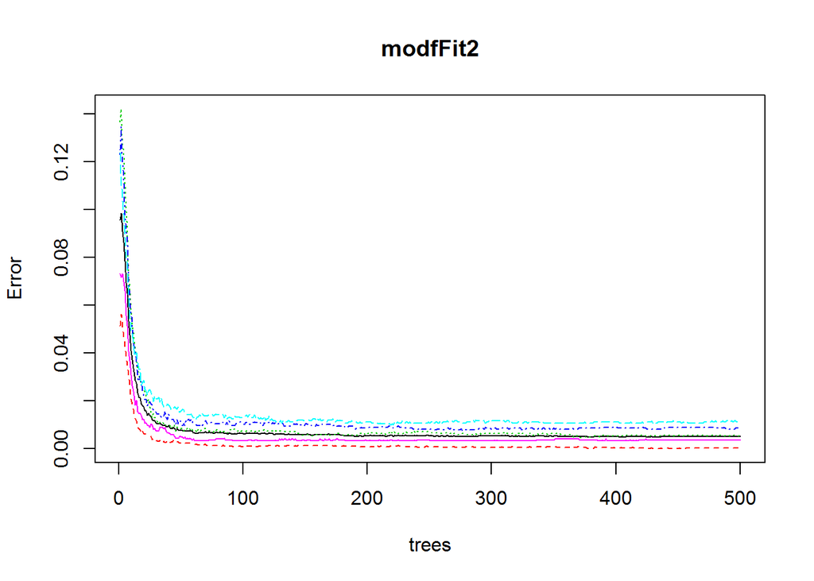

```r
plot(modfFit2)
```

The resulted accuracy is 99.8% with Random Forest prediction using the training data set.

## Run the predictions with Testing Data for the project using the Random Forest Model

```r
PredictionsTEST <- predict(modfFit2, TestData, type = "class")
PredictionsTEST
```

```
##  1  2  3  4  5  6  7  8  9 10 11 12 13 14 15 16 17 18 19 20
##  B  A  B  A  A  E  D  B  A  A  B  C  B  A  E  E  A  B  B  B
## Levels: A B C D E
```

## Conclusion

The prediction of test data set containing 20 records using the random forest with an accuracy of 0.998 resulted in out of sample of error rate of 0.002.

## Writing the results to a text file for submission

```r
path = "~/Data Sciences/Practical Machine Learning/Project/Answers"
pml_write_files = function(x) {
  n = length(x)
  for(i in 1: n) {
    filename = paste0("problem_id_", i, ".txt")
    write.table(x[i], file=file.path(path, filename),
                quote=FALSE, row.names=FALSE, col.names=FALSE)
  }
}
pml_write_files(PredictionsTEST)
```